# Lab 9 - Scientific reports with Rmarkdown

Sophie Tattrie

March 26, 2026

# Learning Objectives

1. Use R markdown syntax for formatting, including headings, lists, tables, and inline code
2. Modify code chunk options (`echo`, `eval`, `include`, `fig.width`)
3. Combine what we’ve learned about spatial and temporal data to interpret and plot movement data of a tagged basking shark
4. Render a scientific report using `knitr` as an HTML

# Part 1: R Markdown Basics

Before we dive into shark data, let’s practice some R Markdown fundamentals. This section demonstrates key formatting features, you’ll use these skills when writing up your analysis later. We’ve been working in `Visual` mode, but you can always check the `Source` view to see examples from this (or other) exercises.

## 1.1 Headings

Headings are created with `#` symbols. More `#` = smaller heading:

```
# Heading 1 (largest)
## Heading 2
### Heading 3
#### Heading 4 (smallest)
```

## 1.2 Text formatting

You can make text **bold** with double asterisks: `**bold**`

You can make text *italic* with single asterisks: `*italic*`

You can make text *bold and italic* with triple asterisks: `***bold and italic***`

You can create `inline code` with backticks: `` `inline code` ``

## 1.3 Lists

**Bullet lists** use `-` or `*`:

- First
- Second
  - Nested item (indent with 2 spaces)
  - Another nested item
- Third

**Numbered lists** use numbers:

1. First
2. Second
3. Third

## 1.4 Links and images

Links use this format: `[text](url)`

Example: [Basking Shark Wikipedia](https://en.wikipedia.org/wiki/Basking_shark) , <- check what this looks like in source view.

Images use `![text](path)` The path here is relative to the RMD file which is `Lab9/Script`, so the path for the figure is `../Figures/Vertebra.jpg`

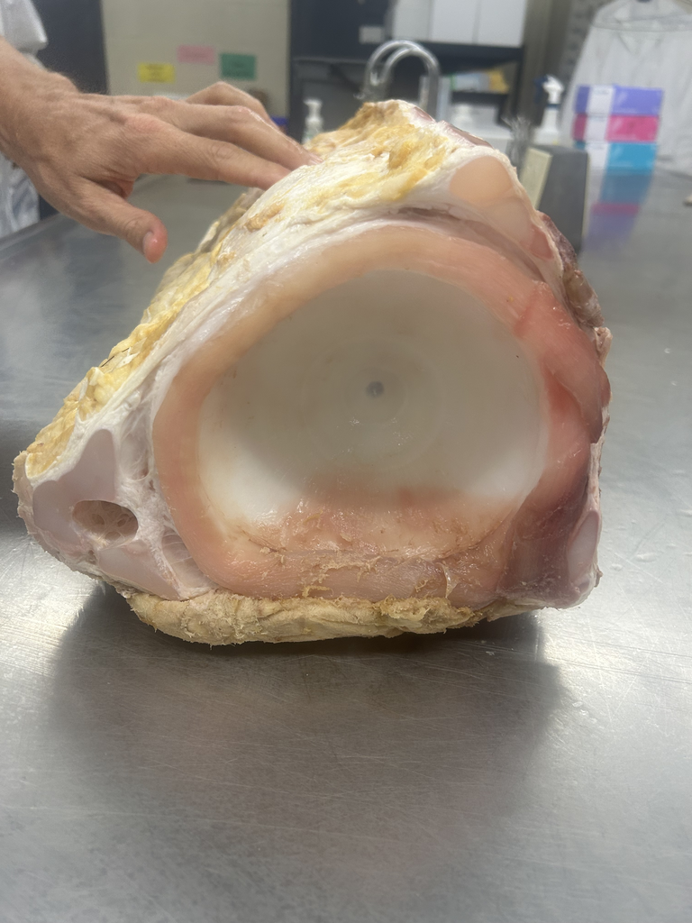

Basking shark vertebra

OR, you can embed them the following way. The path can be tricky when knitting depending on where your directory is, if you have major issues go with the URL approach. Notice the path here is different from above, and now relative to the knit working directory. Confusing!

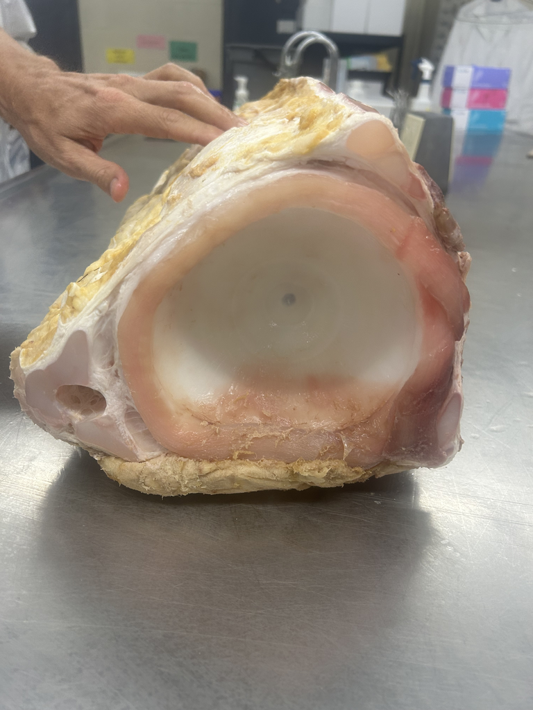

## 1.5 Tables in Markdown

You can create simple tables manually:

| Species | Max Length (m) | Feeding mechanism |
| --- | --- | --- |
| Basking shark | 12 | Filter feeder |
| Great white | 6 | Chomper |
| Whale shark | 18 | Filter feeder |

The syntax looks like this:

```
| Column 1 | Column 2 |
|----------|----------|
| Data 1   | Data 2   |
```

These look very pretty when knit together, but they can be cumbersome.

## 1.6 Code chunks

Code chunks are where we have been coding: They start with `` ```{r} `` and end with `` ``` `` .

You can name chunks and set options for how the chunk will render when knit:

- `echo = FALSE` — hides the code, shows only output
- `eval = FALSE` — shows code but doesn’t run it
- `include = FALSE` — runs code but hides everything
- `fig.width =` — sets figure width in inches (can also set `fig.height =...` ) - defaults are width=7 and height=5

```
## [1] 4400
```

```r
# This code is displayed but not executed
install.packages("ggplot2")  # You wouldn't want this running every knit!
```

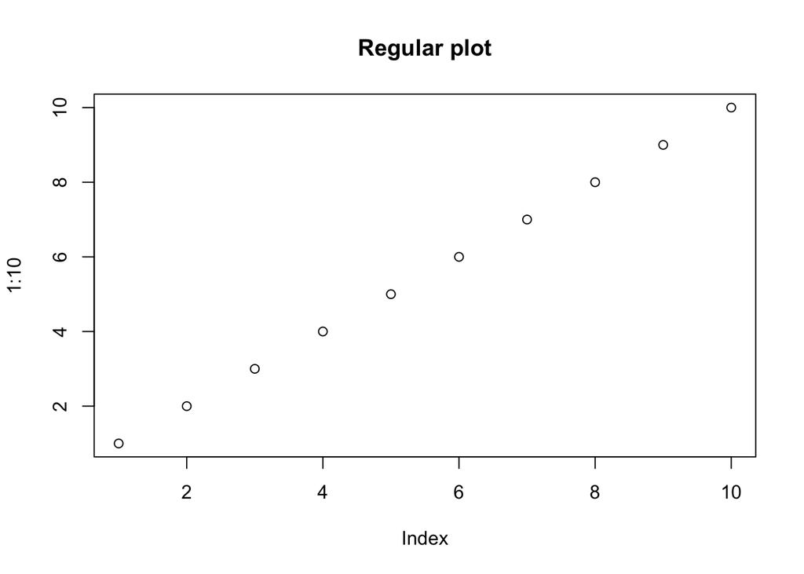

```r
plot(1:10, main = "Regular plot")
```

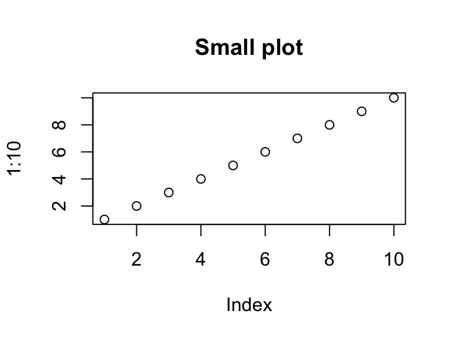

```r
#these settings are smaller than the default
plot(1:10, main = "Small plot")
```

## 1.7 Inline R code

You can embed R results in text using backticks with `r`:

The `basking shark` is the coolest shark.

### EXERCISE 1: Practice formatting

Move to source view and practice by writing the following in the space below.

1. A level-3 heading with your name
2. A sentence with **bold** and *italic* text
3. A bullet list of 3 marine animals
4. A simple 2-column table

*Add your practice content here:*

### Tabitha

**my name is** *tabitha*

- cuttlefish
- jellyfish
- wolffish

| Fish 1 | Fish 2 |
| --- | --- |
| blue | orange |

# Part 2: Setup and Data

Now let’s load our packages and data.

## 2.1 Load packages

```r
packages <- c("tidyverse", "sf", "rnaturalearth", "rnaturalearthdata")

# Install packages not yet installed
installed_packages <- packages %in% installed.packages()

if (any(installed_packages == FALSE)) {
  install.packages(packages[!installed_packages])
}

# Packages loading
invisible(lapply(packages, library, character.only = TRUE))
```

## 2.2 Load spatial polygons

We’ll use Natural Earth data to get coastlines (as we’ve been doing).

```r
# Country polygons for the Americas
coast <- ne_countries(scale = "medium", returnclass = "sf")

# Ocean polygon
ocean <- ne_download(scale = "medium",
                     type = "ocean",
                     category = "physical",
                     returnclass = "sf")
```

## 2.3 Load shark tracking data

```r
# Download shark tracking data directly, ERDDAP servers often go down for maintenance, looks like that's currently the case
#sharks <- read.csv("https://erddap.bco-dmo.org/erddap/tabledap/bcodmo_dataset_476315.csv",
                   #skip = 1)  # Skip the units row

#We'll load the csv directly to be safe
sharks <- read.csv("../Data/basking_sharks.csv")
sharks <- sharks[-1,]

# Clean column names
colnames(sharks) <- c("ptt", "tuid", "year", "month", "day", "longitude", "latitude",
                      "date", "type", "depth_min", "temp_depth_min", "depth_max",
                      "depth_range", "tsst")

# Convert date column and add month name
sharks <- sharks %>%
  mutate(
    across(c(ptt, tuid, year, month, day, longitude, latitude,
             depth_min, temp_depth_min, depth_max, depth_range, tsst), as.numeric),
    date = as.Date(date, format = "%m/%d/%Y"),
    month_name = month.abb[month]
  )


# Convert to spatial object
sharks_sf <- st_as_sf(sharks,
                      coords = c("longitude", "latitude"),
                      crs = 4326)
```

## 2.4 Explore available sharks

```r
shark_summary <- sharks %>%
  group_by(ptt) %>%
  summarise(
    n_locations = n(),
    start_date = min(date, na.rm = TRUE),
    end_date = max(date, na.rm = TRUE),
    days_tracked = as.numeric(end_date - start_date),
    min_lat = min(latitude),
    max_lat = max(latitude)
  ) %>%
  arrange(desc(days_tracked))

#kable turns a dataframe into a nicely formatted table, much better than the raw output of shark_summary
knitr::kable(shark_summary,
             digits = 1)
```

| ptt | n_locations | start_date | end_date | days_tracked | min_lat | max_lat |
| --- | --- | --- | --- | --- | --- | --- |
| 88136 | 110 | 2008-10-11 | 2009-10-01 | 355 | 21.8 | 43.4 |
| 88139 | 89 | 2008-10-11 | 2009-10-01 | 355 | 32.9 | 42.0 |
| 88143 | 62 | 2008-10-11 | 2009-10-01 | 355 | 29.7 | 42.4 |
| 96003 | 230 | 2011-06-08 | 2012-04-02 | 299 | 35.4 | 41.2 |
| 95981 | 135 | 2011-06-08 | 2012-04-01 | 298 | 27.3 | 43.4 |
| 95982 | 209 | 2011-06-08 | 2012-04-01 | 298 | 36.9 | 41.0 |
| 88137 | 99 | 2008-10-11 | 2009-08-01 | 294 | 19.9 | 42.2 |
| 100979 | 121 | 2011-06-27 | 2012-04-01 | 279 | 20.6 | 42.5 |
| 95997 | 194 | 2011-06-05 | 2012-03-02 | 271 | 34.7 | 42.4 |
| 67810 | 198 | 2006-09-06 | 2007-06-01 | 268 | 31.8 | 42.6 |
| 67813 | 117 | 2006-09-06 | 2007-06-01 | 268 | 27.5 | 42.2 |
| 96002 | 237 | 2011-06-08 | 2012-03-02 | 268 | 34.1 | 41.2 |
| 52556 | 44 | 2005-07-21 | 2006-04-03 | 256 | -4.4 | 41.7 |
| 52562 | 40 | 2005-10-03 | 2006-06-02 | 242 | -2.1 | 42.0 |
| 100974 | 44 | 2011-06-27 | 2012-02-12 | 230 | 34.4 | 42.4 |
| 52563 | 64 | 2005-07-21 | 2006-02-15 | 209 | 24.4 | 41.7 |
| 88144 | 53 | 2010-08-21 | 2011-02-26 | 189 | 40.7 | 44.4 |
| 52557 | 34 | 2005-08-26 | 2006-02-16 | 174 | 9.4 | 42.1 |
| 110493 | 78 | 2011-09-21 | 2012-02-01 | 133 | 16.5 | 42.1 |
| 110499 | 45 | 2011-09-21 | 2012-02-01 | 133 | 34.8 | 42.1 |
| 110500 | 40 | 2011-09-21 | 2012-02-01 | 133 | 18.6 | 42.1 |
| 110501 | 31 | 2011-09-21 | 2012-02-01 | 133 | 35.4 | 43.4 |
| 110503 | 42 | 2011-09-21 | 2012-02-01 | 133 | 35.9 | 42.8 |
| 52559 | 57 | 2004-09-24 | 2005-01-31 | 129 | 18.6 | 41.2 |
| 109841 | 85 | 2011-08-23 | 2011-12-22 | 121 | 29.8 | 41.7 |

```r
## same as summary() but looks nicer, digits = 1 means that its rounding the numbers in the output
```

## 2.5 Plot their migration

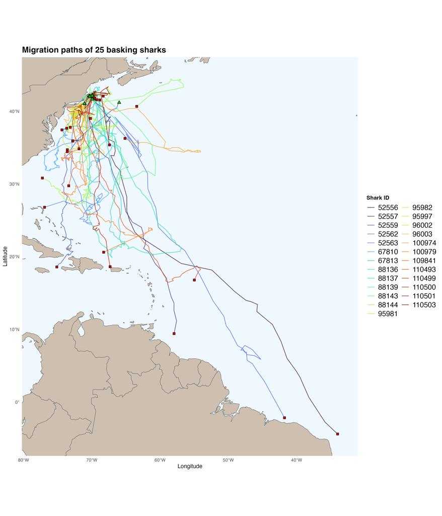